# Graduate Attribute Course Report: ENGR 460

Jake Kaupp

2017-03-16

# 1 Introduction

The following is a course-level report on the Graduate Attribute Assessment and Continuous Improvement Process efforts in ENGR. It should help provide a view into the performance of each cohort and potentially reveal some aspects of the program that could be considered for future improvement.

# 2 Graduate Attribute Overview

The following chart represents the aggregate student performance on each indicator for each graduate attribute assessed in the course. Each data point represents the mean score achieved for a single indicator for each respective attribute. The points are horizontally dodged to reduce over plotting, with dividing lines showing the bounds for each performance category. The chart is interactive, and displays additional details when you hover over each point.

[interactive chart not shown]

# 3 Graduate Attribute Assessment Focus

This chart represents the assessment focus of course, presenting the attributes and indicators assessed in the course and how many times they are assessed. The larger the attribute grouping (area by colour) the more indicators are assessed for that attribute. The larger the area of the individual indicator boxes, the more times that indicator is assessed in the course.

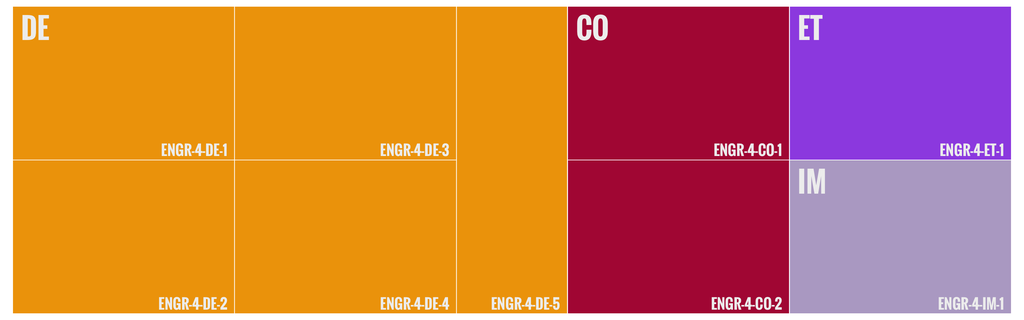

# 4 Assessment Level Student Performance Distributions

The following table presents course mapping information integrated with histograms depicting student performance for each distinct assessment of a particular indicator. The mapping information provides a detailed view of how attributes and indicators are mapped to and assessed in a course. It provides contextual information such as assessor, context, date and any instructor comments made regarding the assessment data. Missing items are labelled as “NA”.

The small histograms (sparklines) are aggregates of student performance on the indicators assessed in the course. The distributions are presented percentages of the cohort attaining a particular level. The histograms are interactive and will display the the performance level and percentage on mouse over. You can filter the results using the search bar at the top of the table.

| Indicator | Description | Assessment | Assessor | Week Assessed | Instructor Comments | Students Assessed | 2015-2016 |
| --- | --- | --- | --- | --- | --- | --- | --- |
| ENGR-4-CO-1 |  | Final Report Rubric | Instructor | 13 |  | 25 | 0,12,24,64,0 |
| ENGR-4-CO-2 |  | Final Report Rubric | Instructor | 13 |  | 25 | 4,8,20,60,8 |
| ENGR-4-DE-1 |  | Final Report Rubric | Instructor | 13 |  | 25 | 4,0,16,56,24 |
| ENGR-4-DE-2 |  | Final Report Rubric | Instructor | 13 |  | 25 | 0,24,20,44,12 |
| ENGR-4-DE-3 |  | Final Report Rubric | Instructor | 13 |  | 25 | 4,20,16,52,8 |
| ENGR-4-DE-4 |  | Final Report Rubric | Instructor | 13 |  | 25 | 0,0,88,12,0 |
| ENGR-4-DE-5 |  | Final Report Rubric | Instructor | 13 |  | 25 | 24,40,36,0,0 |
| ENGR-4-ET-1 |  | Final Report Rubric | Instructor | 13 |  | 25 | 4,20,24,52,0 |
| ENGR-4-IM-1 |  | Final Report Rubric | Instructor | 13 |  | 25 | 0,0,20,68,12 |